# Risk Factor Analysis

## Outcome Variable

**Outcome Variable:** ever_swasted

## Predictor Variables

**Intervention Variable:** vagbrth

**Adjustment Set:**

- arm
- sex
- W_mage
- meducyrs
- feducyrs
- hhwealth_quart
- W_mhtcm
- single
- brthmon
- W_parity
- delta_W_mage
- delta_meducyrs
- delta_feducyrs
- delta_hhwealth_quart
- delta_W_mhtcm
- delta_single
- delta_brthmon
- delta_W_parity

## Stratifying Variables

The analysis was stratified on these variable(s):

- agecat
- studyid
- country

## Data Summary

| agecat | studyid | country | vagbrth | ever_swasted | n_cell | n |
| --- | --- | --- | --- | --- | --- | --- |
| 0-24 months (no birth wast) | ki1000108-CMC-V-BCS-2002 | INDIA | 0 | 0 | 20 | 368 |
| 0-24 months (no birth wast) | ki1000108-CMC-V-BCS-2002 | INDIA | 0 | 1 | 5 | 368 |
| 0-24 months (no birth wast) | ki1000108-CMC-V-BCS-2002 | INDIA | 1 | 0 | 293 | 368 |
| 0-24 months (no birth wast) | ki1000108-CMC-V-BCS-2002 | INDIA | 1 | 1 | 50 | 368 |
| 0-24 months (no birth wast) | ki1000108-IRC | INDIA | 0 | 0 | 55 | 409 |
| 0-24 months (no birth wast) | ki1000108-IRC | INDIA | 0 | 1 | 15 | 409 |
| 0-24 months (no birth wast) | ki1000108-IRC | INDIA | 1 | 0 | 277 | 409 |
| 0-24 months (no birth wast) | ki1000108-IRC | INDIA | 1 | 1 | 62 | 409 |
| 0-24 months (no birth wast) | ki1017093b-PROVIDE | BANGLADESH | 0 | 0 | 158 | 687 |
| 0-24 months (no birth wast) | ki1017093b-PROVIDE | BANGLADESH | 0 | 1 | 1 | 687 |
| 0-24 months (no birth wast) | ki1017093b-PROVIDE | BANGLADESH | 1 | 0 | 510 | 687 |
| 0-24 months (no birth wast) | ki1017093b-PROVIDE | BANGLADESH | 1 | 1 | 18 | 687 |
| 0-24 months (no birth wast) | ki1017093c-NIH-Crypto | BANGLADESH | 0 | 0 | 198 | 496 |
| 0-24 months (no birth wast) | ki1017093c-NIH-Crypto | BANGLADESH | 0 | 1 | 4 | 496 |
| 0-24 months (no birth wast) | ki1017093c-NIH-Crypto | BANGLADESH | 1 | 0 | 284 | 496 |
| 0-24 months (no birth wast) | ki1017093c-NIH-Crypto | BANGLADESH | 1 | 1 | 10 | 496 |
| 0-24 months (no birth wast) | ki1066203-TanzaniaChild2 | TANZANIA, UNITED REPUBLIC OF | 0 | 0 | 195 | 2355 |
| 0-24 months (no birth wast) | ki1066203-TanzaniaChild2 | TANZANIA, UNITED REPUBLIC OF | 0 | 1 | 17 | 2355 |
| 0-24 months (no birth wast) | ki1066203-TanzaniaChild2 | TANZANIA, UNITED REPUBLIC OF | 1 | 0 | 2039 | 2355 |
| 0-24 months (no birth wast) | ki1066203-TanzaniaChild2 | TANZANIA, UNITED REPUBLIC OF | 1 | 1 | 104 | 2355 |
| 0-24 months (no birth wast) | ki1119695-PROBIT | BELARUS | 0 | 0 | 1922 | 16877 |
| 0-24 months (no birth wast) | ki1119695-PROBIT | BELARUS | 0 | 1 | 28 | 16877 |
| 0-24 months (no birth wast) | ki1119695-PROBIT | BELARUS | 1 | 0 | 14751 | 16877 |
| 0-24 months (no birth wast) | ki1119695-PROBIT | BELARUS | 1 | 1 | 176 | 16877 |
| 0-24 months (no birth wast) | ki1126311-ZVITAMBO | ZIMBABWE | 0 | 0 | 1110 | 13510 |
| 0-24 months (no birth wast) | ki1126311-ZVITAMBO | ZIMBABWE | 0 | 1 | 31 | 13510 |
| 0-24 months (no birth wast) | ki1126311-ZVITAMBO | ZIMBABWE | 1 | 0 | 11937 | 13510 |
| 0-24 months (no birth wast) | ki1126311-ZVITAMBO | ZIMBABWE | 1 | 1 | 432 | 13510 |
| 0-24 months (no birth wast) | kiGH5241-JiVitA-3 | BANGLADESH | 0 | 0 | 1454 | 26408 |
| 0-24 months (no birth wast) | kiGH5241-JiVitA-3 | BANGLADESH | 0 | 1 | 36 | 26408 |
| 0-24 months (no birth wast) | kiGH5241-JiVitA-3 | BANGLADESH | 1 | 0 | 24010 | 26408 |
| 0-24 months (no birth wast) | kiGH5241-JiVitA-3 | BANGLADESH | 1 | 1 | 908 | 26408 |
| 0-24 months (no birth wast) | kiGH5241-JiVitA-4 | BANGLADESH | 0 | 0 | 358 | 4499 |
| 0-24 months (no birth wast) | kiGH5241-JiVitA-4 | BANGLADESH | 0 | 1 | 12 | 4499 |
| 0-24 months (no birth wast) | kiGH5241-JiVitA-4 | BANGLADESH | 1 | 0 | 3933 | 4499 |
| 0-24 months (no birth wast) | kiGH5241-JiVitA-4 | BANGLADESH | 1 | 1 | 196 | 4499 |
| 6-24 months | ki1000108-CMC-V-BCS-2002 | INDIA | 0 | 0 | 23 | 373 |
| 6-24 months | ki1000108-CMC-V-BCS-2002 | INDIA | 0 | 1 | 2 | 373 |
| 6-24 months | ki1000108-CMC-V-BCS-2002 | INDIA | 1 | 0 | 320 | 373 |
| 6-24 months | ki1000108-CMC-V-BCS-2002 | INDIA | 1 | 1 | 28 | 373 |
| 6-24 months | ki1000108-IRC | INDIA | 0 | 0 | 66 | 410 |
| 6-24 months | ki1000108-IRC | INDIA | 0 | 1 | 4 | 410 |
| 6-24 months | ki1000108-IRC | INDIA | 1 | 0 | 318 | 410 |
| 6-24 months | ki1000108-IRC | INDIA | 1 | 1 | 22 | 410 |
| 6-24 months | ki1017093b-PROVIDE | BANGLADESH | 0 | 0 | 143 | 615 |
| 6-24 months | ki1017093b-PROVIDE | BANGLADESH | 0 | 1 | 0 | 615 |
| 6-24 months | ki1017093b-PROVIDE | BANGLADESH | 1 | 0 | 459 | 615 |
| 6-24 months | ki1017093b-PROVIDE | BANGLADESH | 1 | 1 | 13 | 615 |
| 6-24 months | ki1017093c-NIH-Crypto | BANGLADESH | 0 | 0 | 190 | 472 |
| 6-24 months | ki1017093c-NIH-Crypto | BANGLADESH | 0 | 1 | 4 | 472 |
| 6-24 months | ki1017093c-NIH-Crypto | BANGLADESH | 1 | 0 | 267 | 472 |
| 6-24 months | ki1017093c-NIH-Crypto | BANGLADESH | 1 | 1 | 11 | 472 |
| 6-24 months | ki1066203-TanzaniaChild2 | TANZANIA, UNITED REPUBLIC OF | 0 | 0 | 175 | 1996 |
| 6-24 months | ki1066203-TanzaniaChild2 | TANZANIA, UNITED REPUBLIC OF | 0 | 1 | 11 | 1996 |
| 6-24 months | ki1066203-TanzaniaChild2 | TANZANIA, UNITED REPUBLIC OF | 1 | 0 | 1738 | 1996 |
| 6-24 months | ki1066203-TanzaniaChild2 | TANZANIA, UNITED REPUBLIC OF | 1 | 1 | 72 | 1996 |
| 6-24 months | ki1119695-PROBIT | BELARUS | 0 | 0 | 1913 | 16598 |
| 6-24 months | ki1119695-PROBIT | BELARUS | 0 | 1 | 6 | 16598 |
| 6-24 months | ki1119695-PROBIT | BELARUS | 1 | 0 | 14659 | 16598 |
| 6-24 months | ki1119695-PROBIT | BELARUS | 1 | 1 | 20 | 16598 |
| 6-24 months | ki1126311-ZVITAMBO | ZIMBABWE | 0 | 0 | 877 | 10605 |
| 6-24 months | ki1126311-ZVITAMBO | ZIMBABWE | 0 | 1 | 27 | 10605 |
| 6-24 months | ki1126311-ZVITAMBO | ZIMBABWE | 1 | 0 | 9385 | 10605 |
| 6-24 months | ki1126311-ZVITAMBO | ZIMBABWE | 1 | 1 | 316 | 10605 |
| 6-24 months | kiGH5241-JiVitA-3 | BANGLADESH | 0 | 0 | 1090 | 17212 |
| 6-24 months | kiGH5241-JiVitA-3 | BANGLADESH | 0 | 1 | 23 | 17212 |
| 6-24 months | kiGH5241-JiVitA-3 | BANGLADESH | 1 | 0 | 15572 | 17212 |
| 6-24 months | kiGH5241-JiVitA-3 | BANGLADESH | 1 | 1 | 527 | 17212 |
| 6-24 months | kiGH5241-JiVitA-4 | BANGLADESH | 0 | 0 | 359 | 4510 |
| 6-24 months | kiGH5241-JiVitA-4 | BANGLADESH | 0 | 1 | 10 | 4510 |
| 6-24 months | kiGH5241-JiVitA-4 | BANGLADESH | 1 | 0 | 3952 | 4510 |
| 6-24 months | kiGH5241-JiVitA-4 | BANGLADESH | 1 | 1 | 189 | 4510 |

The following strata were considered:

- agecat: 0-24 months (no birth wast), studyid: ki1000108-CMC-V-BCS-2002, country: INDIA
- agecat: 0-24 months (no birth wast), studyid: ki1000108-IRC, country: INDIA
- agecat: 0-24 months (no birth wast), studyid: ki1017093b-PROVIDE, country: BANGLADESH
- agecat: 0-24 months (no birth wast), studyid: ki1017093c-NIH-Crypto, country: BANGLADESH
- agecat: 0-24 months (no birth wast), studyid: ki1066203-TanzaniaChild2, country: TANZANIA, UNITED REPUBLIC OF
- agecat: 0-24 months (no birth wast), studyid: ki1119695-PROBIT, country: BELARUS
- agecat: 0-24 months (no birth wast), studyid: ki1126311-ZVITAMBO, country: ZIMBABWE
- agecat: 0-24 months (no birth wast), studyid: kiGH5241-JiVitA-3, country: BANGLADESH
- agecat: 0-24 months (no birth wast), studyid: kiGH5241-JiVitA-4, country: BANGLADESH
- agecat: 6-24 months, studyid: ki1000108-CMC-V-BCS-2002, country: INDIA
- agecat: 6-24 months, studyid: ki1000108-IRC, country: INDIA
- agecat: 6-24 months, studyid: ki1017093b-PROVIDE, country: BANGLADESH
- agecat: 6-24 months, studyid: ki1017093c-NIH-Crypto, country: BANGLADESH
- agecat: 6-24 months, studyid: ki1066203-TanzaniaChild2, country: TANZANIA, UNITED REPUBLIC OF
- agecat: 6-24 months, studyid: ki1119695-PROBIT, country: BELARUS
- agecat: 6-24 months, studyid: ki1126311-ZVITAMBO, country: ZIMBABWE
- agecat: 6-24 months, studyid: kiGH5241-JiVitA-3, country: BANGLADESH
- agecat: 6-24 months, studyid: kiGH5241-JiVitA-4, country: BANGLADESH

### Dropped Strata

Some strata were dropped due to rare outcomes:

- agecat: 0-24 months (no birth wast), studyid: ki1017093b-PROVIDE, country: BANGLADESH
- agecat: 0-24 months (no birth wast), studyid: ki1017093c-NIH-Crypto, country: BANGLADESH
- agecat: 6-24 months, studyid: ki1000108-CMC-V-BCS-2002, country: INDIA
- agecat: 6-24 months, studyid: ki1000108-IRC, country: INDIA
- agecat: 6-24 months, studyid: ki1017093b-PROVIDE, country: BANGLADESH
- agecat: 6-24 months, studyid: ki1017093c-NIH-Crypto, country: BANGLADESH

## Methods Detail

We’re interested in the causal parameters $E[Y_a]$ for all values of $a \in \mathcal{A}$. These parameters represent the mean outcome if, possibly contrary to fact, we intervened to set all units to have $A=a$. Under the randomization and positivity assumptions, these are identified by the statistical parameters $\psi_a=E_W[E_{Y|A,W}(Y|A=a,W)]$. In addition, we’re interested in the mean of $Y$, $E[Y]$ under no intervention (the observed mean). We will estimate these parameters by using SuperLearner to fit the relevant likelihood factors – $E_{Y|A,W}(Y|A=a,W)$ and $p(A=a|W)$, and then updating our likelihood fit using a joint TMLE.

For unadjusted analyses ($W=\{\}$), initial likelihoods were estimated using Lrnr_glm to estimate the simple $E(Y|A)$ and Lrnr_mean to estimate $p(A)$. For adjusted analyses, a small library containing Lrnr_glmnet, Lrnr_xgboost, and Lrnr_mean was used.

Having estimated these parameters, we will then use the delta method to estimate relative risks and attributable risks relative to a prespecified baseline level of $A$.

# Results Detail

## Results Plots

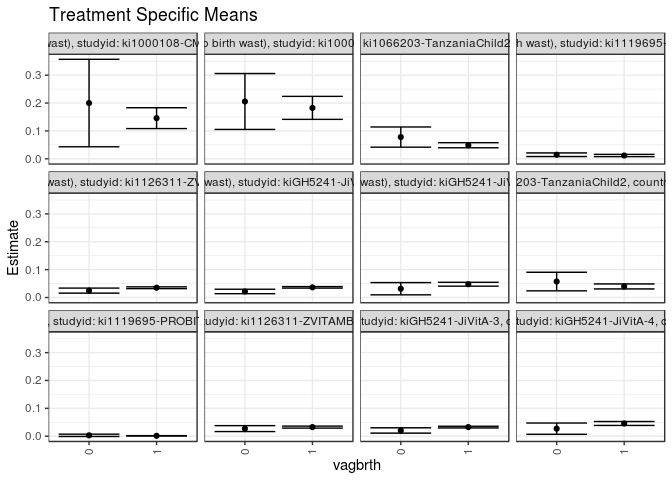

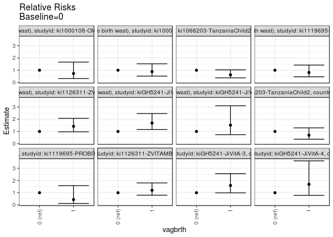

[figure not shown]

[figure not shown]

## Results Table

### Parameter: TSM

| agecat | studyid | country | intervention_level | baseline_level | estimate | ci_lower | ci_upper |
| --- | --- | --- | --- | --- | --- | --- | --- |
| 0-24 months (no birth wast) | ki1000108-CMC-V-BCS-2002 | INDIA | 0 | NA | 0.2000000 | 0.0429894 | 0.3570106 |
| 0-24 months (no birth wast) | ki1000108-CMC-V-BCS-2002 | INDIA | 1 | NA | 0.1457726 | 0.1083773 | 0.1831679 |
| 0-24 months (no birth wast) | ki1000108-IRC | INDIA | 0 | NA | 0.2056100 | 0.1053350 | 0.3058849 |
| 0-24 months (no birth wast) | ki1000108-IRC | INDIA | 1 | NA | 0.1826096 | 0.1413338 | 0.2238853 |
| 0-24 months (no birth wast) | ki1066203-TanzaniaChild2 | TANZANIA, UNITED REPUBLIC OF | 0 | NA | 0.0779079 | 0.0416450 | 0.1141707 |
| 0-24 months (no birth wast) | ki1066203-TanzaniaChild2 | TANZANIA, UNITED REPUBLIC OF | 1 | NA | 0.0485988 | 0.0394908 | 0.0577067 |
| 0-24 months (no birth wast) | ki1119695-PROBIT | BELARUS | 0 | NA | 0.0144463 | 0.0079742 | 0.0209184 |
| 0-24 months (no birth wast) | ki1119695-PROBIT | BELARUS | 1 | NA | 0.0117233 | 0.0076803 | 0.0157663 |
| 0-24 months (no birth wast) | ki1126311-ZVITAMBO | ZIMBABWE | 0 | NA | 0.0246633 | 0.0156161 | 0.0337106 |
| 0-24 months (no birth wast) | ki1126311-ZVITAMBO | ZIMBABWE | 1 | NA | 0.0350149 | 0.0317712 | 0.0382586 |
| 0-24 months (no birth wast) | kiGH5241-JiVitA-3 | BANGLADESH | 0 | NA | 0.0215477 | 0.0135496 | 0.0295459 |
| 0-24 months (no birth wast) | kiGH5241-JiVitA-3 | BANGLADESH | 1 | NA | 0.0363915 | 0.0336886 | 0.0390943 |
| 0-24 months (no birth wast) | kiGH5241-JiVitA-4 | BANGLADESH | 0 | NA | 0.0314362 | 0.0094944 | 0.0533779 |
| 0-24 months (no birth wast) | kiGH5241-JiVitA-4 | BANGLADESH | 1 | NA | 0.0475170 | 0.0405342 | 0.0544998 |
| 6-24 months | ki1066203-TanzaniaChild2 | TANZANIA, UNITED REPUBLIC OF | 0 | NA | 0.0572110 | 0.0239418 | 0.0904802 |
| 6-24 months | ki1066203-TanzaniaChild2 | TANZANIA, UNITED REPUBLIC OF | 1 | NA | 0.0396562 | 0.0306667 | 0.0486458 |
| 6-24 months | ki1119695-PROBIT | BELARUS | 0 | NA | 0.0031266 | -0.0009905 | 0.0072437 |
| 6-24 months | ki1119695-PROBIT | BELARUS | 1 | NA | 0.0013625 | 0.0007667 | 0.0019583 |
| 6-24 months | ki1126311-ZVITAMBO | ZIMBABWE | 0 | NA | 0.0272900 | 0.0165971 | 0.0379830 |
| 6-24 months | ki1126311-ZVITAMBO | ZIMBABWE | 1 | NA | 0.0326764 | 0.0291337 | 0.0362191 |
| 6-24 months | kiGH5241-JiVitA-3 | BANGLADESH | 0 | NA | 0.0205630 | 0.0109868 | 0.0301392 |
| 6-24 months | kiGH5241-JiVitA-3 | BANGLADESH | 1 | NA | 0.0327124 | 0.0296965 | 0.0357283 |
| 6-24 months | kiGH5241-JiVitA-4 | BANGLADESH | 0 | NA | 0.0271140 | 0.0068908 | 0.0473371 |
| 6-24 months | kiGH5241-JiVitA-4 | BANGLADESH | 1 | NA | 0.0456574 | 0.0386355 | 0.0526793 |

### Parameter: E(Y)

| agecat | studyid | country | intervention_level | baseline_level | estimate | ci_lower | ci_upper |
| --- | --- | --- | --- | --- | --- | --- | --- |
| 0-24 months (no birth wast) | ki1000108-CMC-V-BCS-2002 | INDIA | NA | NA | 0.1494565 | 0.1129794 | 0.1859337 |
| 0-24 months (no birth wast) | ki1000108-IRC | INDIA | NA | NA | 0.1882641 | 0.1503318 | 0.2261964 |
| 0-24 months (no birth wast) | ki1066203-TanzaniaChild2 | TANZANIA, UNITED REPUBLIC OF | NA | NA | 0.0513800 | 0.0424616 | 0.0602985 |
| 0-24 months (no birth wast) | ki1119695-PROBIT | BELARUS | NA | NA | 0.0120875 | 0.0084025 | 0.0157724 |
| 0-24 months (no birth wast) | ki1126311-ZVITAMBO | ZIMBABWE | NA | NA | 0.0342709 | 0.0312031 | 0.0373387 |
| 0-24 months (no birth wast) | kiGH5241-JiVitA-3 | BANGLADESH | NA | NA | 0.0357467 | 0.0331646 | 0.0383289 |
| 0-24 months (no birth wast) | kiGH5241-JiVitA-4 | BANGLADESH | NA | NA | 0.0462325 | 0.0396215 | 0.0528435 |
| 6-24 months | ki1066203-TanzaniaChild2 | TANZANIA, UNITED REPUBLIC OF | NA | NA | 0.0415832 | 0.0328230 | 0.0503433 |
| 6-24 months | ki1119695-PROBIT | BELARUS | NA | NA | 0.0015665 | 0.0007872 | 0.0023457 |
| 6-24 months | ki1126311-ZVITAMBO | ZIMBABWE | NA | NA | 0.0323432 | 0.0289761 | 0.0357104 |
| 6-24 months | kiGH5241-JiVitA-3 | BANGLADESH | NA | NA | 0.0319545 | 0.0290590 | 0.0348499 |
| 6-24 months | kiGH5241-JiVitA-4 | BANGLADESH | NA | NA | 0.0441242 | 0.0374527 | 0.0507956 |

### Parameter: RR

| agecat | studyid | country | intervention_level | baseline_level | estimate | ci_lower | ci_upper |
| --- | --- | --- | --- | --- | --- | --- | --- |
| 0-24 months (no birth wast) | ki1000108-CMC-V-BCS-2002 | INDIA | 0 | 0 | 1.0000000 | 1.0000000 | 1.000000 |
| 0-24 months (no birth wast) | ki1000108-CMC-V-BCS-2002 | INDIA | 1 | 0 | 0.7288630 | 0.3191248 | 1.664682 |
| 0-24 months (no birth wast) | ki1000108-IRC | INDIA | 0 | 0 | 1.0000000 | 1.0000000 | 1.000000 |
| 0-24 months (no birth wast) | ki1000108-IRC | INDIA | 1 | 0 | 0.8881357 | 0.5186585 | 1.520818 |
| 0-24 months (no birth wast) | ki1066203-TanzaniaChild2 | TANZANIA, UNITED REPUBLIC OF | 0 | 0 | 1.0000000 | 1.0000000 | 1.000000 |
| 0-24 months (no birth wast) | ki1066203-TanzaniaChild2 | TANZANIA, UNITED REPUBLIC OF | 1 | 0 | 0.6237976 | 0.3776911 | 1.030269 |
| 0-24 months (no birth wast) | ki1119695-PROBIT | BELARUS | 0 | 0 | 1.0000000 | 1.0000000 | 1.000000 |
| 0-24 months (no birth wast) | ki1119695-PROBIT | BELARUS | 1 | 0 | 0.8115062 | 0.4632336 | 1.421620 |
| 0-24 months (no birth wast) | ki1126311-ZVITAMBO | ZIMBABWE | 0 | 0 | 1.0000000 | 1.0000000 | 1.000000 |
| 0-24 months (no birth wast) | ki1126311-ZVITAMBO | ZIMBABWE | 1 | 0 | 1.4197146 | 0.9725592 | 2.072459 |
| 0-24 months (no birth wast) | kiGH5241-JiVitA-3 | BANGLADESH | 0 | 0 | 1.0000000 | 1.0000000 | 1.000000 |
| 0-24 months (no birth wast) | kiGH5241-JiVitA-3 | BANGLADESH | 1 | 0 | 1.6888760 | 1.1577515 | 2.463657 |
| 0-24 months (no birth wast) | kiGH5241-JiVitA-4 | BANGLADESH | 0 | 0 | 1.0000000 | 1.0000000 | 1.000000 |
| 0-24 months (no birth wast) | kiGH5241-JiVitA-4 | BANGLADESH | 1 | 0 | 1.5115389 | 0.7378366 | 3.096553 |
| 6-24 months | ki1066203-TanzaniaChild2 | TANZANIA, UNITED REPUBLIC OF | 0 | 0 | 1.0000000 | 1.0000000 | 1.000000 |
| 6-24 months | ki1066203-TanzaniaChild2 | TANZANIA, UNITED REPUBLIC OF | 1 | 0 | 0.6931573 | 0.3713147 | 1.293962 |
| 6-24 months | ki1119695-PROBIT | BELARUS | 0 | 0 | 1.0000000 | 1.0000000 | 1.000000 |
| 6-24 months | ki1119695-PROBIT | BELARUS | 1 | 0 | 0.4357699 | 0.1200864 | 1.581323 |
| 6-24 months | ki1126311-ZVITAMBO | ZIMBABWE | 0 | 0 | 1.0000000 | 1.0000000 | 1.000000 |
| 6-24 months | ki1126311-ZVITAMBO | ZIMBABWE | 1 | 0 | 1.1973742 | 0.7974390 | 1.797887 |
| 6-24 months | kiGH5241-JiVitA-3 | BANGLADESH | 0 | 0 | 1.0000000 | 1.0000000 | 1.000000 |
| 6-24 months | kiGH5241-JiVitA-3 | BANGLADESH | 1 | 0 | 1.5908404 | 0.9905547 | 2.554905 |
| 6-24 months | kiGH5241-JiVitA-4 | BANGLADESH | 0 | 0 | 1.0000000 | 1.0000000 | 1.000000 |
| 6-24 months | kiGH5241-JiVitA-4 | BANGLADESH | 1 | 0 | 1.6839087 | 0.7870114 | 3.602932 |

### Parameter: PAR

| agecat | studyid | country | intervention_level | baseline_level | estimate | ci_lower | ci_upper |
| --- | --- | --- | --- | --- | --- | --- | --- |
| 0-24 months (no birth wast) | ki1000108-CMC-V-BCS-2002 | INDIA | 0 | NA | -0.0505435 | -0.2009875 | 0.0999006 |
| 0-24 months (no birth wast) | ki1000108-IRC | INDIA | 0 | NA | -0.0173459 | -0.1079213 | 0.0732294 |
| 0-24 months (no birth wast) | ki1066203-TanzaniaChild2 | TANZANIA, UNITED REPUBLIC OF | 0 | NA | -0.0265278 | -0.0605391 | 0.0074834 |
| 0-24 months (no birth wast) | ki1119695-PROBIT | BELARUS | 0 | NA | -0.0023588 | -0.0090838 | 0.0043661 |
| 0-24 months (no birth wast) | ki1126311-ZVITAMBO | ZIMBABWE | 0 | NA | 0.0096076 | 0.0008101 | 0.0184050 |
| 0-24 months (no birth wast) | kiGH5241-JiVitA-3 | BANGLADESH | 0 | NA | 0.0141990 | 0.0062593 | 0.0221386 |
| 0-24 months (no birth wast) | kiGH5241-JiVitA-4 | BANGLADESH | 0 | NA | 0.0147963 | -0.0065199 | 0.0361126 |
| 6-24 months | ki1066203-TanzaniaChild2 | TANZANIA, UNITED REPUBLIC OF | 0 | NA | -0.0156279 | -0.0469063 | 0.0156505 |
| 6-24 months | ki1119695-PROBIT | BELARUS | 0 | NA | -0.0015602 | -0.0051189 | 0.0019985 |
| 6-24 months | ki1126311-ZVITAMBO | ZIMBABWE | 0 | NA | 0.0050532 | -0.0052486 | 0.0153550 |
| 6-24 months | kiGH5241-JiVitA-3 | BANGLADESH | 0 | NA | 0.0113915 | 0.0020281 | 0.0207548 |
| 6-24 months | kiGH5241-JiVitA-4 | BANGLADESH | 0 | NA | 0.0170102 | -0.0026297 | 0.0366502 |

### Parameter: PAF

| agecat | studyid | country | intervention_level | baseline_level | estimate | ci_lower | ci_upper |
| --- | --- | --- | --- | --- | --- | --- | --- |
| 0-24 months (no birth wast) | ki1000108-CMC-V-BCS-2002 | INDIA | 0 | NA | -0.3381818 | -1.8354235 | 0.3684433 |
| 0-24 months (no birth wast) | ki1000108-IRC | INDIA | 0 | NA | -0.0921361 | -0.6954754 | 0.2965033 |
| 0-24 months (no birth wast) | ki1066203-TanzaniaChild2 | TANZANIA, UNITED REPUBLIC OF | 0 | NA | -0.5163062 | -1.3376671 | 0.0164620 |
| 0-24 months (no birth wast) | ki1119695-PROBIT | BELARUS | 0 | NA | -0.1951483 | -0.9406791 | 0.2639796 |
| 0-24 months (no birth wast) | ki1126311-ZVITAMBO | ZIMBABWE | 0 | NA | 0.2803418 | -0.0265708 | 0.4954971 |
| 0-24 months (no birth wast) | kiGH5241-JiVitA-3 | BANGLADESH | 0 | NA | 0.3972109 | 0.1317894 | 0.5814902 |
| 0-24 months (no birth wast) | kiGH5241-JiVitA-4 | BANGLADESH | 0 | NA | 0.3200416 | -0.3387293 | 0.6546401 |
| 6-24 months | ki1066203-TanzaniaChild2 | TANZANIA, UNITED REPUBLIC OF | 0 | NA | -0.3758217 | -1.3711115 | 0.2016886 |
| 6-24 months | ki1119695-PROBIT | BELARUS | 0 | NA | -0.9959915 | -4.3775882 | 0.2591508 |
| 6-24 months | ki1126311-ZVITAMBO | ZIMBABWE | 0 | NA | 0.1562367 | -0.2302696 | 0.4213166 |
| 6-24 months | kiGH5241-JiVitA-3 | BANGLADESH | 0 | NA | 0.3564910 | -0.0133562 | 0.5913540 |
| 6-24 months | kiGH5241-JiVitA-4 | BANGLADESH | 0 | NA | 0.3855078 | -0.2660519 | 0.7017495 |